# Reinforcement Learning for Smart Home EV Charging Optimization

The reinforcement learning experiment on smart home EV charging. It starts from the problem formulation and then adds risk-aware RL methods step by step. This first section sets up the Python environment. It imports the core libraries for numerical computation, data handling, and plotting, and configures global settings for reproducibility.

**Imports and Basic Configuration**

Imports numerical (NumPy), data-handling (pandas), plotting (Matplotlib), optimisation (PuLP), reinforcement-learning (Gymnasium like interfaces), and deep-learning (PyTorch) libraries. Also sets general display options and Matplotlib defaults that will be reused throughout the notebook.

```python
import math
import random
from typing import Tuple, Dict, Any

import numpy as np
import pandas as pd
import matplotlib.pyplot as plt
```

```python
import torch
import torch.nn as nn
import torch.optim as optim
import gymnasium as gym
from gymnasium import spaces

%matplotlib inline

print("Python version:", f"{math.floor(3)}.x (runtime specific)")
print("NumPy version:", np.__version__)
print("Pandas version:", pd.__version__)
print("PyTorch version:", torch.__version__)
print("Gymnasium version:", gym.__version__)
```

```
Python version: 3.x (runtime specific)
NumPy version: 2.0.2
Pandas version: 2.2.2
PyTorch version: 2.9.0+cu126
Gymnasium version: 1.2.2
```

**Reproducibility and Device**

Defines a single global random seed `SEED` and applies it to NumPy and PyTorch so that all stochastic elements (random initialisations, sampling from distributions, train test splits) are repeatable. Detects whether a GPU is available and creates a `device` handle (`cuda` or `cpu`) that is used consistently by all neural-network code.

```python
# Global random seed for reproducibility
SEED = 1227

def set_global_seed(seed: int = SEED) -> None:

    random.seed(seed)
    np.random.seed(seed)
    torch.manual_seed(seed)
    torch.cuda.manual_seed_all(seed)

    # Some additional flags that can make PyTorch more deterministic.
    torch.backends.cudnn.deterministic = True
    torch.backends.cudnn.benchmark = False


set_global_seed(SEED)

# Select device: use GPU if available, otherwise CPU
device = torch.device("cuda" if torch.cuda.is_available() else "cpu")
print(f"Using device: {device}")
print(f"Global SEED set to: {SEED}")
```

```
Using device: cpu
Global SEED set to: 1227
```

# 1.0 Problem setup and simulation calendar

# 1.1 Charging configuration and time grid

- episode start and end times (evening plug-in and morning departure),
- the time-step length Δt in hours,
- the EV battery capacity in kWh,
- the minimum and target state-of-charge (SoC),
- the maximum charging power, and
- the penalty per kWh of unmet energy at the end of the night.

From these values, the code computes the number of discrete time-steps per episode and the corresponding time grid. This configuration object is passed into all subsequent components so that the environment and agents share a consistent definition of the problem.

```python
from dataclasses import dataclass

@dataclass
class ChargingConfig:
    """
    Configuration for the smart home EV charging problem.

    This class collects the main time-related parameters that define a single
    charging episode. Each episode corresponds to one night of charging from
    an evening start time to a morning end time.
    """
    start_hour: int = 18          # charging window opens at 18:00
    end_hour: int = 8             # charging window closes at 08:00 next day
    delta_t_hours: float = 1.0    # time step in hours
    soc_min: float = 0.10         # minimum allowed state of charge (fraction)
    soc_max: float = 1.00         # maximum allowed state of charge (fraction)
    soc_target: float = 0.90      # target state of charge by 08:00
    battery_capacity_kwh: float = 60.0  # EV battery capacity in kWh
    max_charge_kw: float = 7.2    # typical level-2 charger power rating (kW)

    @property
    def steps_per_episode(self) -> int:
        """
        Number of discrete decision steps within one charging episode.

        The end time is assumed to be on the following day, so the episode
        length is computed by wrapping across midnight when needed.
        """
        if self.end_hour > self.start_hour:
            total_hours = self.end_hour - self.start_hour
        else:
            total_hours = (24 - self.start_hour) + self.end_hour

        return int(total_hours / self.delta_t_hours)

    @property
    def time_grid_hours(self) -> np.ndarray:
        """
        Array of physical clock times (in hours) for each decision step
        within a single episode, expressed on a 24-hour clock.
        """
        return (self.start_hour +
                np.arange(self.steps_per_episode) * self.delta_t_hours) % 24


# Instantiate a default configuration and inspect basic properties
config = ChargingConfig()
print("Steps per episode:", config.steps_per_episode)
print("Time grid (hours):", config.time_grid_hours)
print("Battery capacity (kWh):", config.battery_capacity_kwh)
print("Target SoC:", config.soc_target)
```

```
Steps per episode: 14
Time grid (hours): [18. 19. 20. 21. 22. 23.  0.  1.  2.  3.  4.  5.  6.  7.]
Battery capacity (kWh): 60.0
Target SoC: 0.9
```

# 1.2 Calendar construction and season labels

Builds a **synthetic** daily calendar for a full calendar year starting on a chosen date (for example, 1 January 2024). The resulting DataFrame contains one row per date and columns for a sequential `day_index`, a binary `is_weekend` flag, and a categorical `season` label (winter, shoulder, or summer) based on the month. The code also prints or summarises the number of days in each season to verify that the calendar has the expected structure. This calendar provides the exogenous “year context” that drives prices, solar generation, and driving demand.

```python
def build_simulation_calendar(
    start_date: str = "2024-01-01",
    n_days: int = 365
) -> pd.DataFrame:

    dates = pd.date_range(start=start_date, periods=n_days, freq="D")
    day_index = np.arange(n_days)

    # Weekend flag based on pandas weekday convention (Monday=0, Sunday=6)
    is_weekend = (dates.weekday >= 5).astype(int)

    # Simple season rule based on month
    def month_to_season(month: int) -> str:
        if month in (12, 1, 2):
            return "winter"
        elif month in (6, 7, 8):
            return "summer"
        else:
            return "shoulder"

    seasons = [month_to_season(d.month) for d in dates]

    calendar = pd.DataFrame(
        {
            "date": dates,
            "day_index": day_index,
            "is_weekend": is_weekend,
            "season": seasons,
        }
    )

    return calendar


calendar_df = build_simulation_calendar()
calendar_df.head(), calendar_df["season"].value_counts()
```

```
(        date  day_index  is_weekend  season
 0 2024-01-01          0           0  winter
 1 2024-01-02          1           0  winter
 2 2024-01-03          2           0  winter
 3 2024-01-04          3           0  winter
 4 2024-01-05          4           0  winter,
 season
 shoulder    183
 summer       92
 winter       90
 Name: count, dtype: int64)
```

# 2.0 Stylized electricity price model

# 2.1 Tariff configuration and daily price profile

Introduces a `TariffConfig` dataclass that collects parameters for a stylized time-of-use tariff. The configuration includes base prices for off-peak, mid-peak, and on-peak hours, multiplicative adjustments for weekends and seasons, and an optional small noise scale. A helper function then constructs a daily price profile over the episode time grid for a given calendar date. For each time-step, it classifies the hour into off-peak, mid-peak, or on-peak, adjusts the base price according to weekend and season, and adds a small random perturbation if requested. The output is a 1D NumPy array of length `steps_per_episode` containing the **synthetic** electricity price in each time-step of that night.

```python
from dataclasses import dataclass

@dataclass
class TariffConfig:
    """
    Simple time-of-use (TOU) tariff specification for the simulator.

    The model distinguishes three price levels (off-peak, mid-peak, on-peak)
    and allows for simple adjustments by weekend status and season.
    All prices are denominated in USD per kWh.
    """
    tou_offpeak: float = 0.12   # overnight off-peak price
    tou_midpeak: float = 0.18   # daytime price
    tou_onpeak: float = 0.28    # early-evening peak price

    weekend_discount: float = 0.90   # multiply prices on weekends
    summer_multiplier: float = 1.05  # summer scaling factor
    winter_multiplier: float = 0.95  # winter scaling factor
    shoulder_multiplier: float = 1.00

    # Definition of on-peak and mid-peak windows on a 24-hour clock
    onpeak_start_hour: int = 16
    onpeak_end_hour: int = 21   # exclusive upper bound
    midpeak_start_hour: int = 7
    midpeak_end_hour: int = 16  # exclusive upper bound

    noise_std: float = 0.005    # small Gaussian noise to avoid perfectly flat prices


def build_daily_price_profile(
    day_row: pd.Series,
    config: ChargingConfig,
    tariff_cfg: TariffConfig,
    rng: np.random.Generator,
) -> np.ndarray:

    hours = config.time_grid_hours
    prices = np.full_like(hours, fill_value=tariff_cfg.tou_offpeak, dtype=float)

    # Assign mid-peak and on-peak prices based on the clock hour
    for i, h in enumerate(hours):
        if tariff_cfg.onpeak_start_hour <= h < tariff_cfg.onpeak_end_hour:
            prices[i] = tariff_cfg.tou_onpeak
        elif tariff_cfg.midpeak_start_hour <= h < tariff_cfg.midpeak_end_hour:
            prices[i] = tariff_cfg.tou_midpeak
        else:
            prices[i] = tariff_cfg.tou_offpeak

    # Apply weekend discount
    if int(day_row["is_weekend"]) == 1:
        prices *= tariff_cfg.weekend_discount

    # Apply seasonal multipliers
    season = day_row["season"]
    if season == "summer":
        prices *= tariff_cfg.summer_multiplier
    elif season == "winter":
        prices *= tariff_cfg.winter_multiplier
    else:
        prices *= tariff_cfg.shoulder_multiplier

    # Add a small amount of zero-mean noise for realism
    if tariff_cfg.noise_std > 0:
        prices += rng.normal(loc=0.0, scale=tariff_cfg.noise_std, size=prices.shape)

    # Enforce non-negativity
    prices = np.clip(prices, a_min=0.0, a_max=None)

    return prices


# Instantiate a tariff configuration and a NumPy RNG tied to the global seed
tariff_cfg = TariffConfig()
rng = np.random.default_rng(SEED)

# Example: build price profile for the first simulated day
example_day = calendar_df.iloc[0]
example_prices = build_daily_price_profile(example_day, config, tariff_cfg, rng)

print("Example day:", example_day["date"], "| season:", example_day["season"], "| weekend:", example_day["is_weekend"])
print("Prices over the charging window (USD/kWh):")
print(example_prices)
```

```
Example day: 2024-01-01 00:00:00 | season: winter | weekend: 0
Prices over the charging window (USD/kWh):
[0.27070096 0.26765588 0.26971107 0.12092474 0.11193097 0.10829249
 0.10746666 0.11213674 0.10903786 0.10770961 0.11298669 0.11637273
 0.11328457 0.18287308]
```

# 2.2 Example price profiles

Generates example daily price profiles for selected dates (for example, a winter weekday and a summer weekday) and plots them against time-of-night. The plots illustrate that prices are low during overnight off-peak hours, increase during evening peak hours, and are scaled up or down depending on the season. These visual checks confirm that the tariff model produces realistic time-of-use structure and reasonable magnitudes for the simulated experiments.

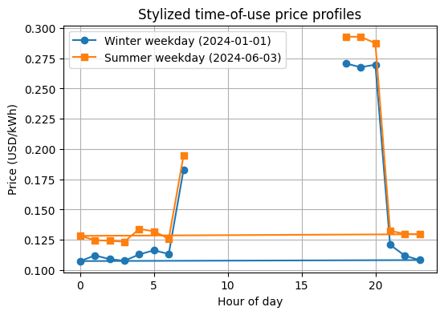

```python
def plot_example_price_profiles(calendar_df, config, tariff_cfg, rng):
    # Pick one winter weekday and one summer weekday
    winter_day = calendar_df[(calendar_df["season"] == "winter") & (calendar_df["is_weekend"] == 0)].iloc[0]
    summer_day = calendar_df[(calendar_df["season"] == "summer") & (calendar_df["is_weekend"] == 0)].iloc[0]

    prices_winter = build_daily_price_profile(winter_day, config, tariff_cfg, rng)
    prices_summer = build_daily_price_profile(summer_day, config, tariff_cfg, rng)

    hours = config.time_grid_hours

    plt.figure(figsize=(6, 4))
    plt.plot(hours, prices_winter, marker="o", label=f"Winter weekday ({winter_day['date'].date()})")
    plt.plot(hours, prices_summer, marker="s", label=f"Summer weekday ({summer_day['date'].date()})")
    plt.xlabel("Hour of day")
    plt.ylabel("Price (USD/kWh)")
    plt.title("Stylized time-of-use price profiles")
    plt.legend()
    plt.grid(True)
    plt.show()


plot_example_price_profiles(calendar_df, config, tariff_cfg, np.random.default_rng(SEED))
```

# 3.0 Stylized rooftop solar (PV) model

# 3.1 PV configuration and daily PV profile

```python
@dataclass
class PvConfig:
    """
    Simple parametric model for rooftop PV generation.

    The model uses a bell-shaped curve around midday, with seasonal and
    random variation in the peak output. Power is expressed in kW at each
    hour of the day.
    """
    system_capacity_kw: float = 5.0      # nominal DC rating of the PV system
    summer_peak_factor: float = 0.9      # fraction of capacity at summer peak
    shoulder_peak_factor: float = 0.7
    winter_peak_factor: float = 0.4

    shape_width_hours: float = 3.5       # controls how spread-out the bell curve is
    noise_std_kw: float = 0.1            # Gaussian noise on the PV profile
    solar_noon_hour: float = 13.0        # approximate solar noon (1 PM local time)


def build_daily_pv_profile(
    day_row: pd.Series,
    config: ChargingConfig,
    pv_cfg: PvConfig,
    rng: np.random.Generator,
) -> np.ndarray:

    hours = config.time_grid_hours

    # Select peak factor based on season
    season = day_row["season"]
    if season == "summer":
        peak_factor = pv_cfg.summer_peak_factor
    elif season == "winter":
        peak_factor = pv_cfg.winter_peak_factor
    else:
        peak_factor = pv_cfg.shoulder_peak_factor

    peak_kw = pv_cfg.system_capacity_kw * peak_factor

    # Bell-shaped curve around solar noon, evaluated only on the charging window
    # Gaussian-like profile: peak at solar_noon_hour, decaying with (hour - noon)^2
    base_profile = peak_kw * np.exp(
        -0.5 * ((hours - pv_cfg.solar_noon_hour) / pv_cfg.shape_width_hours) ** 2
    )

    # PV is effectively zero at night; clip small numerical values
    base_profile = np.clip(base_profile, a_min=0.0, a_max=None)

    # Add random noise to represent day-to-day weather variability
    if pv_cfg.noise_std_kw > 0:
        base_profile += rng.normal(loc=0.0, scale=pv_cfg.noise_std_kw, size=base_profile.shape)

    # Ensure non-negativity after noise
    pv_kw = np.clip(base_profile, a_min=0.0, a_max=None)

    return pv_kw


pv_cfg = PvConfig()

# Example: PV profile for same example day
example_pv = build_daily_pv_profile(example_day, config, pv_cfg, np.random.default_rng(SEED))
print("PV output over the charging window (kW):")
print(example_pv)
```

```
PV output over the charging window (kW):
[0.81491483 0.49325026 0.344892   0.28523418 0.03193557 0.
 0.         0.         0.         0.         0.05304991 0.19419397
 0.25636196 0.69759418]
```

# 3.2 Example PV profiles

Plots sample PV profiles for representative winter and summer days restricted to the charging window. These figures show negligible PV during the middle of the night and higher output in the shoulder periods for summer than for winter. The comparison verifies that the PV model captures the expected seasonal differences and timing, even though it is deliberately simple.

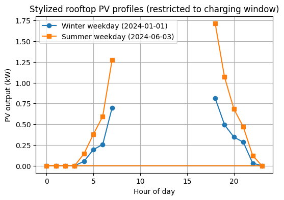

```python
def plot_example_pv_profiles(calendar_df, config, pv_cfg):
    winter_day = calendar_df[(calendar_df["season"] == "winter") & (calendar_df["is_weekend"] == 0)].iloc[0]
    summer_day = calendar_df[(calendar_df["season"] == "summer") & (calendar_df["is_weekend"] == 0)].iloc[0]

    pv_winter = build_daily_pv_profile(winter_day, config, pv_cfg, np.random.default_rng(SEED))
    pv_summer = build_daily_pv_profile(summer_day, config, pv_cfg, np.random.default_rng(SEED))

    hours = config.time_grid_hours

    plt.figure(figsize=(6, 4))
    plt.plot(hours, pv_winter, marker="o", label=f"Winter weekday ({winter_day['date'].date()})")
    plt.plot(hours, pv_summer, marker="s", label=f"Summer weekday ({summer_day['date'].date()})")
    plt.xlabel("Hour of day")
    plt.ylabel("PV output (kW)")
    plt.title("Stylized rooftop PV profiles (restricted to charging window)")
    plt.legend()
    plt.grid(True)
    plt.show()


plot_example_pv_profiles(calendar_df, config, pv_cfg)
```

# 4.0 Next-day driving energy demand model

# 4.1 Log-normal driving demand and summary

Introduces a `DrivingDemandConfig` dataclass and a function that samples next-day driving energy requirements. The model uses separate log-normal distributions for weekdays and weekends with user-specified means and standard deviations in kWh, and caps the sampled demand at a maximum value (for example, 40 kWh) to avoid unrealistically long trips. Given a calendar date, the sampler draws a single `required_kwh` value describing how much energy must be available in the battery to cover the next day’s driving. The code then simulates multiple draws and plots histograms for weekdays and weekends, verifying that typical values lie in a plausible range and that there is sufficient variability for the learning problem.

```python
@dataclass
class DrivingDemandConfig:
    """
    Parametric model for next-day driving energy demand.

    Daily driving demand is represented as a random variable measured in kWh.
    Weekday and weekend demands follow different log-normal distributions so
    that weekdays cluster around a typical commute distance, whereas weekends
    have more variability and occasional long trips.
    """
    # Approximate mean daily energy demand (in kWh)
    weekday_mean_kwh: float = 14.0   # e.g., ~40–50 km of driving
    weekend_mean_kwh: float = 10.0   # lower average, but more variability

    # Coefficients of variation (standard deviation / mean) for log-normal
    weekday_cv: float = 0.35
    weekend_cv: float = 0.60

    # Upper cap to avoid unrealistically large outliers
    max_daily_kwh: float = 40.0


def _lognormal_params_from_mean_cv(mean: float, cv: float) -> Tuple[float, float]:
    """
    Convert a desired mean and coefficient of variation into the mu and sigma
    parameters of a log-normal distribution.

    For a log-normal random variable X ~ LogNormal(mu, sigma^2),
    mean = exp(mu + 0.5 * sigma^2)
    var  = (exp(sigma^2) - 1) * exp(2 * mu + sigma^2)
    """
    variance = (cv * mean) ** 2
    sigma2 = math.log(1.0 + variance / (mean ** 2))
    sigma = math.sqrt(sigma2)
    mu = math.log(mean) - 0.5 * sigma2
    return mu, sigma


def sample_daily_driving_energy(
    day_row: pd.Series,
    drive_cfg: DrivingDemandConfig,
    rng: np.random.Generator,
) -> float:

    is_weekend = int(day_row["is_weekend"])

    if is_weekend == 1:
        mean = drive_cfg.weekend_mean_kwh
        cv = drive_cfg.weekend_cv
    else:
        mean = drive_cfg.weekday_mean_kwh
        cv = drive_cfg.weekday_cv

    mu, sigma = _lognormal_params_from_mean_cv(mean, cv)
    sample = rng.lognormal(mean=mu, sigma=sigma)

    # Cap extreme outliers and enforce non-negativity
    required_kwh = float(np.clip(sample, a_min=0.0, a_max=drive_cfg.max_daily_kwh))
    return required_kwh


drive_cfg = DrivingDemandConfig()

# Example: sample driving demand for first 5 days
rng_drive = np.random.default_rng(SEED)
for i in range(5):
    day = calendar_df.iloc[i]
    demand = sample_daily_driving_energy(day, drive_cfg, rng_drive)
    print(day["date"].date(), "weekend=", day["is_weekend"], "required_kwh=", round(demand, 1))
```

```
2024-01-01 weekend= 0 required_kwh= 18.2
2024-01-02 weekend= 0 required_kwh= 14.8
2024-01-03 weekend= 0 required_kwh= 17.0
2024-01-04 weekend= 0 required_kwh= 21.2
2024-01-05 weekend= 0 required_kwh= 11.5
```

To inspect the implied driving model, the next cell samples many synthetic days and plots histograms of weekday and weekend energy requirements. Weekdays should concentrate around a typical commute level, while weekends should show more spread and a heavier tail.

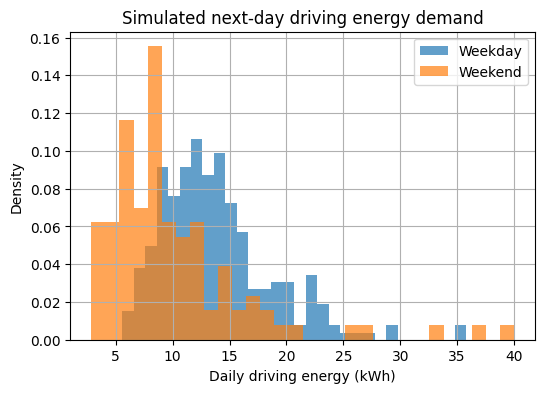

```python
def plot_driving_demand_histograms(calendar_df, drive_cfg, n_samples: int = 5000):
    rng_local = np.random.default_rng(SEED)

    weekday_rows = calendar_df[calendar_df["is_weekend"] == 0].sample(
        n=min(n_samples, len(calendar_df[calendar_df["is_weekend"] == 0])),
        replace=True,
        random_state=SEED,
    )
    weekend_rows = calendar_df[calendar_df["is_weekend"] == 1].sample(
        n=min(n_samples, len(calendar_df[calendar_df["is_weekend"] == 1])),
        replace=True,
        random_state=SEED + 1,
    )

    weekday_samples = [
        sample_daily_driving_energy(row, drive_cfg, rng_local)
        for _, row in weekday_rows.iterrows()
    ]
    weekend_samples = [
        sample_daily_driving_energy(row, drive_cfg, rng_local)
        for _, row in weekend_rows.iterrows()
    ]

    plt.figure(figsize=(6, 4))
    plt.hist(weekday_samples, bins=30, alpha=0.7, label="Weekday", density=True)
    plt.hist(weekend_samples, bins=30, alpha=0.7, label="Weekend", density=True)
    plt.xlabel("Daily driving energy (kWh)")
    plt.ylabel("Density")
    plt.title("Simulated next-day driving energy demand")
    plt.legend()
    plt.grid(True)
    plt.show()


plot_driving_demand_histograms(calendar_df, drive_cfg)
```

# 5.0 Smart EV charging environment (Gym-style MDP)

# 5.1 Environment state, action, and dynamics

Implements the `SmartEvChargingEnv` class that encapsulates one overnight EV-charging episode as a Markov decision process with a Gym-like interface. The observation at each time-step is a real-valued vector consisting of the following,

- (i) the normalised time index,
- (ii) the current SoC,
- (iii) the normalised electricity price,
- (iv) the normalised PV power,
- (v) the normalised required energy for the next day,
- (vi) a weekend indicator, and
- (vii) a one-hot or encoded representation of the season.

The action space is a discrete set of charging power levels between 0 and the maximum charger rating. The environment updates the SoC according to the chosen power, the time-step length, and the battery capacity, and clips the SoC to admissible bounds. The per-step reward is the negative of the grid energy cost in that step. At the end of the episode, the environment computes the required SoC implied by the next-day energy demand and the nominal SoC target, and applies an additional penalty proportional to any shortfall in kWh. The `reset` method initialises the SoC, samples a date and next-day demand from the calendar and driving model, and constructs the corresponding price and PV profiles.

```python
class SmartEvChargingEnv(gym.Env):
    """
    Gym-style environment for single-EV smart home charging.

    Observation (continuous vector)
    --------------------------------
    The observation encodes the current time, battery state, and exogenous
    signals in a normalized form:

        obs = [
            t_frac,             # normalized time index in [0, 1]
            soc,                # state of charge in [0, 1]
            price_norm,         # current price normalized to a reference level
            pv_norm,            # current PV output normalized by system capacity
            required_frac,      # required next-day energy as fraction of capacity
            is_weekend,         # 0 or 1
            season_code         # -1 (winter), 0 (shoulder), +1 (summer)
        ]

    Action (discrete)
    -----------------
    A discrete action a in {0, ..., n_action_levels-1} is converted to a
    charging power level between 0 and config.max_charge_kw. This represents
    a coarse discretization of the charger setpoint.

    Reward
    ------
    At each step, the environment computes the cost of grid energy as

        step_cost = grid_energy_kwh * price_t,

    where grid_energy_kwh is the portion of charging energy that cannot be
    supplied by rooftop PV. The reward is defined as

        r_t = - step_cost.

    At the terminal step, a shortfall penalty is added if the final SoC is
    below an effective required level determined by the next-day driving
    energy and the nominal SoC target.
    """

    metadata = {"render_modes": ["human"]}

    def __init__(
        self,
        config: ChargingConfig,
        tariff_cfg: TariffConfig,
        pv_cfg: PvConfig,
        drive_cfg: DrivingDemandConfig,
        calendar_df: pd.DataFrame,
        day_indices: np.ndarray | None = None,
        n_action_levels: int = 5,
        shortfall_penalty_per_kwh: float = 0.6,
        seed: int = SEED,
    ):
        super().__init__()

        self.config = config
        self.tariff_cfg = tariff_cfg
        self.pv_cfg = pv_cfg
        self.drive_cfg = drive_cfg
        self.calendar_df = calendar_df.reset_index(drop=True)
        self.day_indices = (
            np.array(day_indices, dtype=int)
            if day_indices is not None
            else np.arange(len(self.calendar_df), dtype=int)
        )
        self.n_action_levels = n_action_levels
        self.shortfall_penalty_per_kwh = shortfall_penalty_per_kwh

        # Random number generator
        self.np_rng = np.random.default_rng(seed)

        # Precompute reference values for normalization
        self.price_ref = max(
            tariff_cfg.tou_onpeak * tariff_cfg.summer_multiplier, 0.01
        )
        self.pv_ref = max(pv_cfg.system_capacity_kw, 0.01)

        # Observation and action spaces
        obs_low = np.array(
            [0.0,           # t_frac
             0.0,           # soc
             0.0,           # price_norm
             0.0,           # pv_norm
             0.0,           # required_frac
             0.0,           # is_weekend
             -1.0],         # season_code
            dtype=np.float32,
        )
        obs_high = np.array(
            [1.0,           # t_frac
             1.0,           # soc
             2.0,           # price_norm (allow some headroom)
             2.0,           # pv_norm
             1.0,           # required_frac (capped at full capacity)
             1.0,           # is_weekend
             1.0],          # season_code
            dtype=np.float32,
        )
        self.observation_space = spaces.Box(low=obs_low, high=obs_high, dtype=np.float32)
        self.action_space = spaces.Discrete(n_action_levels)

        # Internal state variables
        self.current_day_idx: int | None = None
        self.day_row: pd.Series | None = None
        self.price_profile: np.ndarray | None = None
        self.pv_profile: np.ndarray | None = None
        self.required_kwh: float | None = None

        self.t_index: int = 0
        self.soc: float = self.config.soc_target  # initial SoC can be adjusted
        self.episode_cost: float = 0.0


    # Helper methods
    @staticmethod
    def _season_to_code(season: str) -> float:
        if season == "winter":
            return -1.0
        elif season == "summer":
            return 1.0
        else:
            return 0.0

    def _action_to_power_kw(self, action: int) -> float:
        """
        Map discrete action index to a charging power level in kW.
        """
        if self.n_action_levels <= 1:
            return 0.0
        fraction = action / (self.n_action_levels - 1)
        return fraction * self.config.max_charge_kw

    def _get_obs(self) -> np.ndarray:
        """
        Construct the current observation vector from internal state.
        """
        t_frac = self.t_index / max(self.config.steps_per_episode - 1, 1)
        price_t = self.price_profile[self.t_index]
        pv_t = self.pv_profile[self.t_index]

        price_norm = price_t / self.price_ref
        pv_norm = pv_t / self.pv_ref
        required_frac = min(
            1.0,
            (self.required_kwh or 0.0) / self.config.battery_capacity_kwh,
        )

        is_weekend = float(self.day_row["is_weekend"])
        season_code = self._season_to_code(self.day_row["season"])

        obs = np.array(
            [
                t_frac,
                self.soc,
                price_norm,
                pv_norm,
                required_frac,
                is_weekend,
                season_code,
            ],
            dtype=np.float32,
        )
        return obs


    # Gym API methods

    def reset(self, *, seed: int | None = None, options: Dict[str, Any] | None = None):
        """
        Start a new episode by sampling a day from the calendar and generating
        price, PV, and driving-demand profiles for that day.
        """
        if seed is not None:
            # Update internal RNG if an external seed is provided
            self.np_rng = np.random.default_rng(seed)

        # Sample a day index uniformly from the allowed set
        self.current_day_idx = int(self.np_rng.choice(self.day_indices))
        self.day_row = self.calendar_df.iloc[self.current_day_idx]

        # Generate exogenous profiles for this day
        self.price_profile = build_daily_price_profile(
            self.day_row, self.config, self.tariff_cfg, self.np_rng
        )
        self.pv_profile = build_daily_pv_profile(
            self.day_row, self.config, self.pv_cfg, self.np_rng
        )
        self.required_kwh = sample_daily_driving_energy(
            self.day_row, self.drive_cfg, self.np_rng
        )

        # Reset internal state
        self.t_index = 0

        # Start-of-night SoC; this could be randomized, but for now it is
        # initialized slightly below the nominal target to keep the problem
        # non-trivial.
        self.soc = max(self.config.soc_min, self.config.soc_target - 0.2)
        self.episode_cost = 0.0

        obs = self._get_obs()
        info = {
            "day_index": self.current_day_idx,
            "date": self.day_row["date"],
            "required_kwh": self.required_kwh,
        }
        return obs, info

    def step(self, action: int):
        """
        Advance the environment by one time step given a discrete charging action.
        """
        assert self.price_profile is not None and self.pv_profile is not None

        # Map action to charging power and compute charged energy this hour
        power_kw = self._action_to_power_kw(int(action))
        delta_t = self.config.delta_t_hours
        charged_kwh = power_kw * delta_t

        # PV generation during this hour (kW) converted to energy
        pv_kw = self.pv_profile[self.t_index]
        pv_energy_kwh = pv_kw * delta_t

        # Portion of charging supplied by PV vs grid
        grid_energy_kwh = max(0.0, charged_kwh - pv_energy_kwh)

        # Update SoC (energy in battery is soc * capacity)
        capacity = self.config.battery_capacity_kwh
        energy_kwh = self.soc * capacity + charged_kwh
        energy_kwh = np.clip(
            energy_kwh,
            a_min=self.config.soc_min * capacity,
            a_max=self.config.soc_max * capacity,
        )
        self.soc = float(energy_kwh / capacity)

        # Compute step cost and reward
        price_t = self.price_profile[self.t_index]
        step_cost = grid_energy_kwh * price_t
        self.episode_cost += step_cost

        reward = -step_cost
        terminated = False
        truncated = False

        # Check if this is the final decision step in the episode
        self.t_index += 1
        if self.t_index >= self.config.steps_per_episode:
            terminated = True

            # Effective required SoC based on next-day driving and nominal target.
            # Convert required_kwh to an SoC level, then take the max with soc_target.
            required_soc_from_trip = (
                self.required_kwh / self.config.battery_capacity_kwh
            )
            required_soc = max(self.config.soc_target, required_soc_from_trip)
            required_soc = np.clip(required_soc, self.config.soc_min, self.config.soc_max)

            shortfall = max(0.0, required_soc - self.soc)
            shortfall_kwh = shortfall * capacity
            shortfall_penalty = self.shortfall_penalty_per_kwh * shortfall_kwh

            self.episode_cost += shortfall_penalty
            reward -= shortfall_penalty  # more negative if there is a shortfall

        # Build observation for the next state (or repeat final state if terminated)
        if not terminated:
            obs = self._get_obs()
        else:
            # Keep the last state for completeness
            self.t_index = self.config.steps_per_episode - 1
            obs = self._get_obs()

        info = {
            "day_index": self.current_day_idx,
            "date": self.day_row["date"],
            "required_kwh": self.required_kwh,
            "step_cost": step_cost,
            "grid_energy_kwh": grid_energy_kwh,
            "pv_energy_kwh": pv_energy_kwh,
            "price": price_t,
            "soc": self.soc,
            "episode_cost": self.episode_cost,
            "terminated": terminated,
        }
        return obs, reward, terminated, truncated, info

    def render(self):
        """
        Minimal text-based render showing the current time, SoC, and price.
        """
        hour = self.config.time_grid_hours[self.t_index]
        print(
            f"t={self.t_index} (hour {hour:.0f}), "
            f"SoC={self.soc:.3f}, "
            f"price={self.price_profile[self.t_index]:.3f} $/kWh"
        )
```

# 5.2 Random policy smoke test

```python
# Instantiate a training environment with all days available
env = SmartEvChargingEnv(
    config=config,
    tariff_cfg=tariff_cfg,
    pv_cfg=pv_cfg,
    drive_cfg=drive_cfg,
    calendar_df=calendar_df,
    day_indices=None,
    n_action_levels=5,
    shortfall_penalty_per_kwh=0.6,
    seed=SEED,
)

# Run a few random episodes as a sanity check
n_test_episodes = 20
for ep in range(n_test_episodes):
    obs, info = env.reset()
    done = False
    while not done:
        action = env.action_space.sample()
        obs, reward, terminated, truncated, info = env.step(action)
        done = terminated or truncated

    print(
        f"Episode {ep}: date={info['date'].date()}, "
        f"required_kwh={info['required_kwh']:.1f}, "
        f"final_soc={info['soc']:.2f}, "
        f"episode_cost=${info['episode_cost']:.2f}"
    )
```

```
Episode 0: date=2024-12-12, required_kwh=15.1, final_soc=1.00, episode_cost=$7.32
Episode 1: date=2024-06-12, required_kwh=10.2, final_soc=1.00, episode_cost=$8.35
Episode 2: date=2024-10-02, required_kwh=11.6, final_soc=1.00, episode_cost=$7.80
Episode 3: date=2024-09-05, required_kwh=16.1, final_soc=1.00, episode_cost=$8.64
Episode 4: date=2024-06-19, required_kwh=14.6, final_soc=1.00, episode_cost=$8.60
Episode 5: date=2024-05-21, required_kwh=22.6, final_soc=1.00, episode_cost=$8.51
Episode 6: date=2024-03-20, required_kwh=10.9, final_soc=1.00, episode_cost=$4.09
Episode 7: date=2024-03-28, required_kwh=16.6, final_soc=1.00, episode_cost=$5.98
Episode 8: date=2024-02-12, required_kwh=19.9, final_soc=1.00, episode_cost=$8.98
Episode 9: date=2024-02-19, required_kwh=12.9, final_soc=1.00, episode_cost=$4.46
Episode 10: date=2024-12-18, required_kwh=10.7, final_soc=1.00, episode_cost=$8.35
Episode 11: date=2024-08-16, required_kwh=12.8, final_soc=1.00, episode_cost=$6.85
Episode 12: date=2024-08-02, required_kwh=10.0, final_soc=1.00, episode_cost=$9.35
Episode 13: date=2024-04-07, required_kwh=6.7, final_soc=1.00, episode_cost=$4.71
Episode 14: date=2024-05-30, required_kwh=6.5, final_soc=1.00, episode_cost=$7.31
Episode 15: date=2024-04-26, required_kwh=15.7, final_soc=1.00, episode_cost=$6.01
Episode 16: date=2024-04-20, required_kwh=20.7, final_soc=1.00, episode_cost=$7.01
Episode 17: date=2024-08-05, required_kwh=16.9, final_soc=1.00, episode_cost=$7.21
Episode 18: date=2024-06-18, required_kwh=11.0, final_soc=1.00, episode_cost=$9.04
Episode 19: date=2024-10-05, required_kwh=6.5, final_soc=1.00, episode_cost=$5.24
```

# 6.0 Evaluation helper for fixed policies

# 6.1 Generic policy evaluation routine

```python
from typing import Callable, List

def evaluate_policy(
    env: SmartEvChargingEnv,
    policy_fn: Callable[[SmartEvChargingEnv, np.ndarray], int],
    n_episodes: int = 50,
) -> pd.DataFrame:

    records: List[dict] = []

    for ep in range(n_episodes):
        obs, info = env.reset()
        done = False

        while not done:
            action = policy_fn(env, obs)
            obs, reward, terminated, truncated, info = env.step(action)
            done = terminated or truncated

        records.append(
            {
                "episode": ep,
                "date": info["date"],
                "day_index": info["day_index"],
                "required_kwh": info["required_kwh"],
                "final_soc": info["soc"],
                "episode_cost": info["episode_cost"],
            }
        )

    return pd.DataFrame.from_records(records)
```